# DA410_Assignment5_MattGraham

```r
library(nnspat)  # used for dist2full()
library("dplyr")  # used to select numeric datatypes
library("ggplot2")
library(reshape)  # used for melting matricies
library(klaR)
library(ggvis)
library(class)
library(gmodels)
library(MASS)
```

## 9.7 -

### Do a classification analysis on the beetle data in Table 5.5

Setting up data

```r
beetles <- read.table("C:/mattgraham93.github.io/school/22_3_DA410/data/T5_5_FBEETLES.DAT", header=FALSE)
colnames(beetles) <- c("Experiment", 'Species', 'post_dist', 'l_elytra','len_sec_an', 'len_thi_an')

oleracea <- beetles[beetles$Species==1, -c(1:2)]  # we assume that species 1 = oleracea
carduorum <- beetles[beetles$Species==2, -c(1:2)] # we assume that species 2 = carduorum

beetles
```

| Experiment | Species | post_dist | l_elytra | len_sec_an | len_thi_an |
| --- | --- | --- | --- | --- | --- |
| 1 | 1 | 189 | 245 | 137 | 163 |
| 2 | 1 | 192 | 260 | 132 | 217 |
| 3 | 1 | 217 | 276 | 141 | 192 |
| 4 | 1 | 221 | 299 | 142 | 213 |
| 5 | 1 | 171 | 239 | 128 | 158 |
| 6 | 1 | 192 | 262 | 147 | 173 |
| 7 | 1 | 213 | 278 | 136 | 201 |
| 8 | 1 | 192 | 255 | 128 | 185 |
| 9 | 1 | 170 | 244 | 128 | 192 |
| 10 | 1 | 201 | 276 | 146 | 186 |

[output cut: 29 more lines]

```r
cov.ol <- cov(oleracea)
cov.ca <- cov(carduorum)

n1 <- nrow(oleracea)
n2 <- nrow(carduorum)

df1 <- n1 - 1
df2 <- n2 - 1

s.pl <- ( (df1 * cov.ol) + (df2 * cov.ca) ) / (df1 + df2)

as.data.frame(s.pl)
```

|  | post_dist | l_elytra | len_sec_an | len_thi_an |
| --- | --- | --- | --- | --- |
| post_dist | 143.55910 | 151.8034 | 42.52660 | 71.99253 |
| l_elytra | 151.80341 | 367.7878 | 121.87653 | 106.24467 |
| len_sec_an | 42.52660 | 121.8765 | 118.31408 | 42.06401 |
| len_thi_an | 71.99253 | 106.2447 | 42.06401 | 208.07290 |

Finding column means and z.bar

```r
means.ol <- colMeans(oleracea)
means.ca <- colMeans(carduorum)

z.bar <- (means.ol - means.ca) %*% solve(s.pl)

z.ol <- z.bar - means.ol
z.ca <- z.bar - means.ca
```

z.bar

```r
as.data.frame(z.bar)
```

| post_dist | l_elytra | len_sec_an | len_thi_an |
| --- | --- | --- | --- |
| 0.345249 | -0.1303878 | -0.1064338 | -0.1433533 |

z.ol

```r
as.data.frame(z.ol)
```

| post_dist | l_elytra | len_sec_an | len_thi_an |
| --- | --- | --- | --- |
| -194.1284 | -267.183 | -137.4749 | -186.0907 |

z.ca

```r
as.data.frame(z.ca)
```

| post_dist | l_elytra | len_sec_an | len_thi_an |
| --- | --- | --- | --- |
| -179.2048 | -290.9304 | -157.3064 | -209.3934 |

Finding our cut-off point

```r
cutoff <- (z.ol + z.ca) / 2
as.data.frame(cutoff)
```

| post_dist | l_elytra | len_sec_an | len_thi_an |
| --- | --- | --- | --- |
| -186.6666 | -279.0567 | -147.3906 | -197.742 |

#### (b) Find the classification table using the linear classification function in part (a).

```r
beetle.lda <- lda(Species ~ post_dist + l_elytra + len_sec_an + len_thi_an, data=beetles)
beetle.lda
```

```
## Call:
## lda(Species ~ post_dist + l_elytra + len_sec_an + len_thi_an,
##     data = beetles)
##
## Prior probabilities of groups:
##         1         2
## 0.4871795 0.5128205
##
## Group means:
##   post_dist l_elytra len_sec_an len_thi_an
## 1  194.4737 267.0526   137.3684   185.9474
## 2  179.5500 290.8000   157.2000   209.2500
##
## Coefficients of linear discriminants:
##                    LD1
## post_dist  -0.09327642
## l_elytra    0.03522706
## len_sec_an  0.02875538
## len_thi_an  0.03872998
```

We can see our linear discriminant agree with the sentiment above. We have 3 primary factors that will inherently increase the likelihood that we assign a beetle to class 2, with post_dist being what levels the playing field to provide us with the likelihood of having of class 1.

```r
beetle.predict <- predict(beetle.lda, beetles)$class
table(beetles$Species, beetle.predict, dnn = c('Actual group', 'Predicted group'))
```

```
##             Predicted group
## Actual group  1  2
##            1 19  0
##            2  1 19
```

Error rate:

```r
err.rate <- 1 / (n1+n2)
err.rate
```

```
## [1] 0.02564103
```

Overall, we can conclude our model does a great job at predicting a beetle’s species within ~2.5%. That’s statistically significant, and can be improved!

#### (c) Find the classificaion table using the nearest neighbor method.

```r
set.seed(1234)

beetle.ind <- sample(2, nrow(beetles), replace=TRUE, prob = c(0.67, 0.33))
beetle.training <- beetles[beetle.ind==1, 3:6]
beetle.test <- beetles[beetle.ind==2, 3:6]

beetle.trainingLabels <- beetles[beetle.ind==1,2]
beetle.testLabels <- beetles[beetle.ind==2,2]

beetle.knn.pred <- knn(train=beetle.training, test=beetle.test, cl=beetle.trainingLabels, k=5)

beetleTestLabels <- data.frame(beetle.testLabels)

merge <- data.frame(beetle.knn.pred, beetleTestLabels)
merge
```

| beetle.knn.pred | beetle.testLabels |
| --- | --- |
| 1 | 1 |
| 1 | 1 |
| 1 | 1 |
| 1 | 1 |
| 2 | 2 |
| 2 | 2 |
| 2 | 2 |
| 1 | 2 |
| 2 | 2 |

```r
CrossTable(x=beetle.testLabels, y=beetle.knn.pred, prop.chisq=FALSE)
```

```
##
##
##    Cell Contents
## |-------------------------|
## |                       N |
## |           N / Row Total |
## |           N / Col Total |
## |         N / Table Total |
## |-------------------------|
##
##
## Total Observations in Table:  9
##
##
##                   | beetle.knn.pred
## beetle.testLabels |         1 |         2 | Row Total |
## ------------------|-----------|-----------|-----------|
##                 1 |         4 |         0 |         4 |
##                   |     1.000 |     0.000 |     0.444 |
##                   |     0.800 |     0.000 |           |
##                   |     0.444 |     0.000 |           |
## ------------------|-----------|-----------|-----------|
##                 2 |         1 |         4 |         5 |
##                   |     0.200 |     0.800 |     0.556 |
##                   |     0.200 |     1.000 |           |
##                   |     0.111 |     0.444 |           |
## ------------------|-----------|-----------|-----------|
##      Column Total |         5 |         4 |         9 |
##                   |     0.556 |     0.444 |           |
## ------------------|-----------|-----------|-----------|
##
##
```

## 9.12 -

### Do a classification analysis on the rootstock data of Table 6.2

```r
root <- read.table("C:/mattgraham93.github.io/school/22_3_DA410/data/T6_2_ROOT.DAT", header=FALSE)
colnames(root) <- c('Rootstock', 'girth_4', 'growth_4', 'girth_15', 'weight_15')

k <- 6
p <- 4
n <- 8

root
```

| Rootstock | girth_4 | growth_4 | girth_15 | weight_15 |
| --- | --- | --- | --- | --- |
| 1 | 1.11 | 2.569 | 3.58 | 0.760 |
| 1 | 1.19 | 2.928 | 3.75 | 0.821 |
| 1 | 1.09 | 2.865 | 3.93 | 0.928 |
| 1 | 1.25 | 3.844 | 3.94 | 1.009 |
| 1 | 1.11 | 3.027 | 3.60 | 0.766 |
| 1 | 1.08 | 2.336 | 3.51 | 0.726 |
| 1 | 1.11 | 3.211 | 3.98 | 1.209 |
| 1 | 1.16 | 3.037 | 3.62 | 0.750 |
| 2 | 1.05 | 2.074 | 4.09 | 1.036 |
| 2 | 1.17 | 2.885 | 4.06 | 1.094 |

[output cut: 38 more lines]

#### (a) Find the linear classification functions.

Finding s.pl

```r
root.s.pl <- matrix(0, nrow = p, ncol = p)

for(i in 1:k) {
  root.s.pl <- root.s.pl + cov(root[root$Rootstock == i, 2:5]) / k
}

as.data.frame(root.s.pl)
```

|  | girth_4 | growth_4 | girth_15 | weight_15 |
| --- | --- | --- | --- | --- |
| girth_4 | 0.00761875 | 0.04039437 | 0.01319256 | 0.00517000 |
| growth_4 | 0.04039437 | 0.28911405 | 0.10389554 | 0.05024318 |
| girth_15 | 0.01319256 | 0.10389554 | 0.10216220 | 0.05908705 |
| weight_15 | 0.00517000 | 0.05024318 | 0.05908705 | 0.04101249 |

Finding ybar

```r
ybar <- matrix(nrow = p, ncol = k)
rownames(ybar) <- colnames(root[, 2:5])
for(i in 1:k) {
  ybar[,i] <- colMeans(root[root$Rootstock == i, 2:5])
}
as.data.frame(ybar)
```

|  | V1 | V2 | V3 | V4 | V5 | V6 |
| --- | --- | --- | --- | --- | --- | --- |
| girth_4 | 1.137500 | 1.157500 | 1.107500 | 1.09750 | 1.08000 | 1.036250 |
| growth_4 | 2.977125 | 3.109125 | 2.815250 | 2.87975 | 2.55725 | 2.214625 |
| girth_15 | 3.738750 | 4.515000 | 4.455000 | 3.90625 | 4.31250 | 3.596250 |
| weight_15 | 0.871125 | 1.280500 | 1.391375 | 1.03900 | 1.18100 | 0.735000 |

Completing classification function

```r
classification <- matrix(nrow = p + 1, ncol = k)
rownames(classification) <- c('c0','c1','c2','c3','c4')

for(i in 1:k) {
  classification[1, i] <- ybar[,i]%*%solve(root.s.pl)%*%as.matrix(ybar[,i]/2)

  classification[2:(p+1), i] <-ybar[,i]%*%solve(root.s.pl)
}
as.data.frame(classification)
```

|  | V1 | V2 | V3 | V4 | V5 | V6 |
| --- | --- | --- | --- | --- | --- | --- |
| c0 | 299.98047 | 353.15985 | 328.49312 | 291.8181 | 347.54494 | 315.79619 |
| c1 | 314.63998 | 317.11988 | 324.58920 | 307.2601 | 316.76668 | 311.30097 |
| c2 | -59.41719 | -63.98083 | -65.15229 | -59.3731 | -65.82568 | -63.06005 |
| c3 | 149.61051 | 168.16143 | 154.91041 | 147.6523 | 168.22072 | 160.62208 |
| c4 | -161.17769 | -172.64428 | -150.35643 | -153.3870 | -172.85120 | -175.47759 |

Above is the complete classification analysis across all rootstocks and measurements. We can see some interesting variability across c3.

#### (b) Find the classification table using the linear classification functions in part (a) (assuming Σ1 = Σ2 = Σ3).

```r
roots.lda <- lda(Rootstock ~ girth_4 + growth_4 + girth_15 + weight_15, data=root)
roots.lda
```

```
## Call:
## lda(Rootstock ~ girth_4 + growth_4 + girth_15 + weight_15, data = root)
##
## Prior probabilities of groups:
##         1         2         3         4         5         6
## 0.1666667 0.1666667 0.1666667 0.1666667 0.1666667 0.1666667
##
## Group means:
##   girth_4 growth_4 girth_15 weight_15
## 1 1.13750 2.977125  3.73875  0.871125
## 2 1.15750 3.109125  4.51500  1.280500
## 3 1.10750 2.815250  4.45500  1.391375
## 4 1.09750 2.879750  3.90625  1.039000
## 5 1.08000 2.557250  4.31250  1.181000
## 6 1.03625 2.214625  3.59625  0.735000
##
## Coefficients of linear discriminants:
##                  LD1        LD2       LD3       LD4
## girth_4    3.0479952  -1.140083 -1.002448 23.419063
## growth_4  -1.7025953  -1.215888  1.672714 -3.076804
## girth_15   4.2332645   7.166403  3.045553 -2.011416
## weight_15 -0.4785144 -11.520302 -5.506192  3.101660
##
## Proportion of trace:
##    LD1    LD2    LD3    LD4
## 0.6421 0.2707 0.0784 0.0089
```

Getting predictions

```r
roots.lda.pred <- predict(roots.lda)$class
table(root$Rootstock, roots.lda.pred, dnn=c("Actual group", "Predicted group"))
```

```
##             Predicted group
## Actual group 1 2 3 4 5 6
##            1 5 0 0 1 0 2
##            2 0 3 2 1 2 0
##            3 0 0 6 1 1 0
##            4 3 0 1 4 0 0
##            5 0 3 1 0 3 1
##            6 2 0 0 0 2 4
```

Defining accuracy

```r
correct <- sum(roots.lda.pred==root$Rootstock)
total <- nrow(root)

root.pred.perc <- correct / total
root.pred.err <- 1 - root.pred.perc

root.pred.err
```

```
## [1] 0.4791667
```

We did not produce a very strong model using linear discriminant analysis. This would not be something to use in real life.

#### (c) Find the classification table using quadratic classification functions (assuming population covariance matrices are not equal).

QDA

```r
roots.qda <- qda(Rootstock ~ girth_4 + growth_4 + girth_15 + weight_15, data=root)
roots.qda
```

```
## Call:
## qda(Rootstock ~ girth_4 + growth_4 + girth_15 + weight_15, data = root)
##
## Prior probabilities of groups:
##         1         2         3         4         5         6
## 0.1666667 0.1666667 0.1666667 0.1666667 0.1666667 0.1666667
##
## Group means:
##   girth_4 growth_4 girth_15 weight_15
## 1 1.13750 2.977125  3.73875  0.871125
## 2 1.15750 3.109125  4.51500  1.280500
## 3 1.10750 2.815250  4.45500  1.391375
## 4 1.09750 2.879750  3.90625  1.039000
## 5 1.08000 2.557250  4.31250  1.181000
## 6 1.03625 2.214625  3.59625  0.735000
```

QDA predictions

```r
roots.qda.pred <- predict(roots.qda)$class

table(root$Rootstock, roots.qda.pred, dnn = c("Actual group", 'Predicted group'))
```

```
##             Predicted group
## Actual group 1 2 3 4 5 6
##            1 8 0 0 0 0 0
##            2 0 7 0 1 0 0
##            3 1 0 6 0 1 0
##            4 0 0 1 7 0 0
##            5 0 3 0 0 4 1
##            6 2 0 0 0 1 5
```

Defining accuracy

```r
correct <- sum(roots.qda.pred==root$Rootstock)
total <- nrow(root)

root.pred.perc <- correct / total
root.pred.err <- 1 - root.pred.perc

root.pred.err
```

```
## [1] 0.2291667
```

Here, we can see a 50% reduction in error, which is significant, but not significant enough.

#### (d) Find the classification table using the nearest neighbor method.

```r
set.seed(1234)

roots.ind <- sample(2, nrow(root), replace=TRUE, prob = c(0.67, 0.33))
roots.training <- root[roots.ind==1, 2:5]
roots.test <- root[roots.ind==2, 2:5]

roots.trainingLabels <- root[roots.ind==1,2]
roots.testLabels <- root[roots.ind==2,2]

roots.knn.pred <- knn(train=roots.training, test=roots.test, cl=roots.trainingLabels, k=5)

rootsTestLabels <- data.frame(roots.testLabels)

roots.merge <- data.frame(roots.knn.pred, rootsTestLabels)
roots.merge
```

| roots.knn.pred | roots.testLabels |
| --- | --- |
| 1.19 | 1.11 |
| 1.2 | 1.11 |
| 1.17 | 1.15 |
| 1.11 | 1.19 |
| 1.05 | 1.03 |
| 1.05 | 1.01 |
| 1.05 | 0.99 |
| 1.15 | 1.05 |
| 1.02 | 1.05 |
| 1.2 | 1.13 |

[output cut: 1 more lines]

Determining accuracy

```r
CrossTable(x=roots.testLabels, y=roots.knn.pred, prop.chisq=FALSE)
```

```
##
##
##    Cell Contents
## |-------------------------|
## |                       N |
## |           N / Row Total |
## |           N / Col Total |
## |         N / Table Total |
## |-------------------------|
##
##
## Total Observations in Table:  11
##
##
##                  | roots.knn.pred
## roots.testLabels |      1.02 |      1.05 |      1.09 |      1.11 |      1.15 |      1.17 |      1.19 |       1.2 | Row Total |
## -----------------|-----------|-----------|-----------|-----------|-----------|-----------|-----------|-----------|-----------|
##             0.99 |         0 |         1 |         0 |         0 |         0 |         0 |         0 |         0 |         1 |
##                  |     0.000 |     1.000 |     0.000 |     0.000 |     0.000 |     0.000 |     0.000 |     0.000 |     0.091 |
##                  |     0.000 |     0.333 |     0.000 |     0.000 |     0.000 |     0.000 |     0.000 |     0.000 |           |
##                  |     0.000 |     0.091 |     0.000 |     0.000 |     0.000 |     0.000 |     0.000 |     0.000 |           |
## -----------------|-----------|-----------|-----------|-----------|-----------|-----------|-----------|-----------|-----------|
##             1.01 |         0 |         1 |         0 |         0 |         0 |         0 |         0 |         0 |         1 |
##                  |     0.000 |     1.000 |     0.000 |     0.000 |     0.000 |     0.000 |     0.000 |     0.000 |     0.091 |
##                  |     0.000 |     0.333 |     0.000 |     0.000 |     0.000 |     0.000 |     0.000 |     0.000 |           |
##                  |     0.000 |     0.091 |     0.000 |     0.000 |     0.000 |     0.000 |     0.000 |     0.000 |           |
## -----------------|-----------|-----------|-----------|-----------|-----------|-----------|-----------|-----------|-----------|
##             1.03 |         0 |         1 |         0 |         0 |         0 |         0 |         0 |         0 |         1 |
##                  |     0.000 |     1.000 |     0.000 |     0.000 |     0.000 |     0.000 |     0.000 |     0.000 |     0.091 |
##                  |     0.000 |     0.333 |     0.000 |     0.000 |     0.000 |     0.000 |     0.000 |     0.000 |           |
##                  |     0.000 |     0.091 |     0.000 |     0.000 |     0.000 |     0.000 |     0.000 |     0.000 |           |
## -----------------|-----------|-----------|-----------|-----------|-----------|-----------|-----------|-----------|-----------|
##             1.05 |         1 |         0 |         0 |         0 |         1 |         0 |         0 |         0 |         2 |
##                  |     0.500 |     0.000 |     0.000 |     0.000 |     0.500 |     0.000 |     0.000 |     0.000 |     0.182 |
##                  |     1.000 |     0.000 |     0.000 |     0.000 |     1.000 |     0.000 |     0.000 |     0.000 |           |
##                  |     0.091 |     0.000 |     0.000 |     0.000 |     0.091 |     0.000 |     0.000 |     0.000 |           |
## -----------------|-----------|-----------|-----------|-----------|-----------|-----------|-----------|-----------|-----------|
##             1.11 |         0 |         0 |         0 |         0 |         0 |         0 |         1 |         1 |         2 |
##                  |     0.000 |     0.000 |     0.000 |     0.000 |     0.000 |     0.000 |     0.500 |     0.500 |     0.182 |
##                  |     0.000 |     0.000 |     0.000 |     0.000 |     0.000 |     0.000 |     1.000 |     0.500 |           |
##                  |     0.000 |     0.000 |     0.000 |     0.000 |     0.000 |     0.000 |     0.091 |     0.091 |           |
```

[output cut: 21 more lines]

I don’t really know how to analyze this table for accuracy. Ultimately, it looks like we were only able to determine one classification correctly. I must have done something wrong.

Decision Tree example

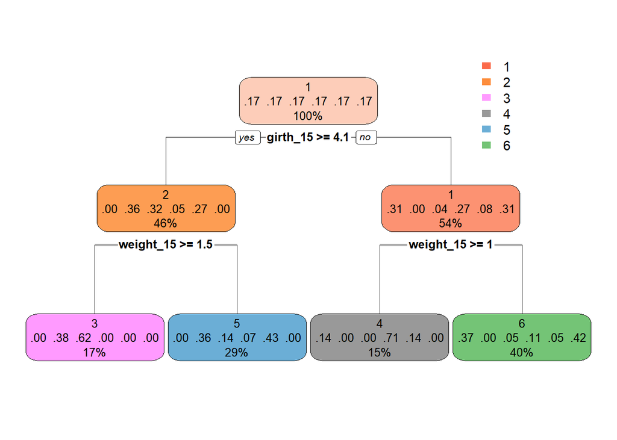

```r
library(rpart)
library(rpart.plot)

fit <- rpart(Rootstock ~ girth_4 + growth_4 + girth_15 + weight_15, data=root, method='class')
rpart.plot(fit)
```